# R proficiency homework

Catherine Zhang

2025-02-06

1. Load relevant software libraries

```r
library(tidyverse)
```

2. Load the mob analysis data

```r
mob = read.csv("https://raw.githubusercontent.com/wellsdata/CompText_Jour/main/data/mob_analysis_data.csv")
```

3. Using code, describe the number of rows and columns in the dataset

```r
nrow(mob)
```

```
## [1] 3836
```

```r
ncol(mob)
```

```
## [1] 7
```

4.Create a table that displays a count of the top 15 newspaper entries

```r
library(janitor)
mob <- janitor::clean_names(mob)

news <- mob %>%
  filter(!is.na(newspaper))%>%  #filter out NAs
  count(newspaper) %>%
  group_by(newspaper) %>%
  arrange(desc(n))
head(news,15)
```

```
## # A tibble: 15 × 2
## # Groups:   newspaper [15]
##    newspaper                                               n
##    <chr>                                               <int>
##  1 The Birmingham age-herald (Birmingham, Ala...)        118
##  2 The daily worker (Chicago, Ill.)                       64
##  3 The Topeka state journal (Topeka, Kansas)              63
##  4 The sun (New York [N.Y.]) 1833-1916                    50
##  5 The Seattle post-intelligencer (Seattle, Wash. ...)    49
##  6 The San Francisco call (San Francisco [...)            46
##  7 The morning news (Savannah, Ga.)                       40
##  8 Los Angeles herald (Los Angeles [Calif.]) 1900-1911    37
##  9 Watertown republican (Watertown, Wis.)                 36
## 10 River Falls journal (River Falls, Pi...)               34
## 11 Vernon County censor (Viroqua, Wis.)                   30
## 12 The Iola register (Iola, Allen Cou...)                 29
## 13 The Daily Ardmoreite (Ardmore, Okla.)                  28
## 14 The Salt Lake herald (Salt Lake City ...)              28
## 15 The semi-weekly messenger (Wilmington, N.C...)         28
```

5. Create a table that counts the different entries in the “keyword” column

```r
keywords <- mob %>%
  count(keyword) %>%
  group_by(keyword) %>%
  arrange(desc(n))
head(keywords)
```

```
## # A tibble: 6 × 2
## # Groups:   keyword [6]
##   keyword        n
##   <chr>      <int>
## 1 mob         3273
## 2 masked       158
## 3 mobs          96
## 4 masked men    94
## 5 a party of    55
## 6 mob's         26
```

6. Create a table that counts all entries by year

```r
year <- mob %>%
  count(year) %>%
  group_by(year) %>%
  arrange(desc(n))
head(year)
```

```
## # A tibble: 6 × 2
## # Groups:   year [6]
##    year     n
##   <int> <int>
## 1  1903   246
## 2  1906   207
## 3  1901   197
## 4  1904   162
## 5  1893   161
## 6  1899   144
```

7. Create a simple column ggplot chart that shows the total entries by year

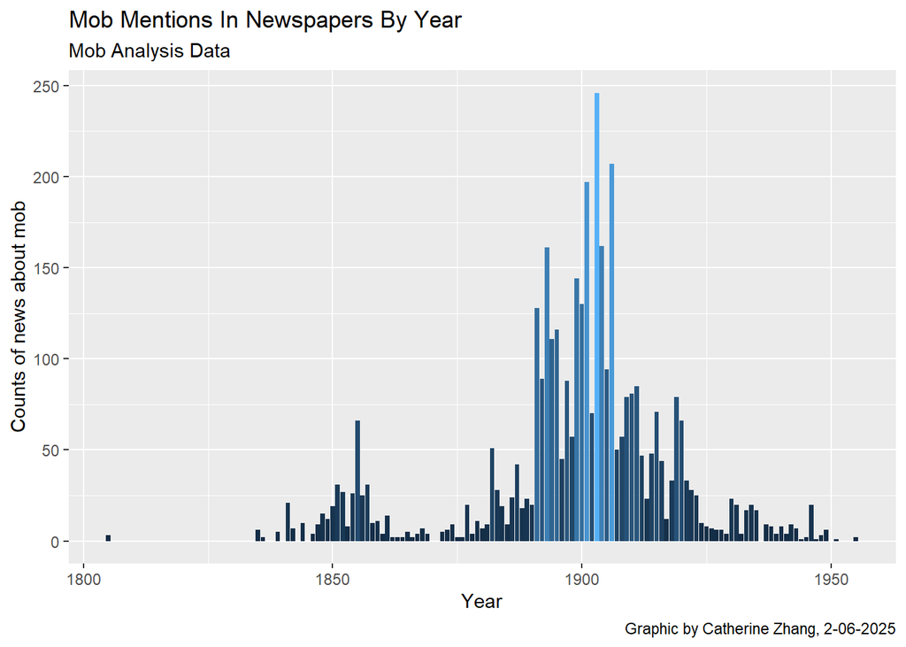

```r
ggplot(year,aes(x = year, y = n,
             fill = n)) +
  geom_col(position = "dodge") +
  theme(legend.position = "none") +
  labs(title = "Mob Mentions In Newspapers By Year",
       subtitle = "Mob Analysis Data",
       caption = "Graphic by Catherine Zhang, 2-06-2025",
       y="Counts of news about mob",
       x="Year")
```

8. Armed with your data analysis, write a 250 word memo at the end of the R markdown document that summarizes your findings. Use this opportunity to ask questions or note any major flaws in the data.

The dataset provides an analysis of newspaper mentions of the keyword “mob” (and its related words) over time. This plot at the end reveals a significant peak in mentions of “mob” between 1880 and 1910, with the highest count recorded in 1903 (246 mentions). Other notable years include 1906 (207 mentions) and 1901 (197 mentions). The decline in mentions after 1910 suggests either a change in media coverage, shifting terminology, or a genuine decrease in mob-related events.

The most frequent sources of these articles (ruled out NAs) include The Birmingham Age-Herald (118 mentions), The Daily Worker (64 mentions), and The Topeka State Journal (63 mentions). The geographic spread of these newspapers highlights possible varied regional concerns regarding mob activity.

Potential Issues and Questions:

1. Data Bias: We do not know the sources of the dataset. Thus, how this is representing the overall picture of mob activities in the United States is unknown.
2. Terminology: The use of term “mob” might change over time. We should figure out if there were alternative terms used in later periods such as after 1920
3. Contextual Analysis: We need further investigation and analysis of what caused the skewed graphic, and why the coverage of mob activities declined after 1920s. For example, we can investigate if there’s any law implements after 1910s. Or, maybe it could be due to missing data. Further investigation could involve analysis of the articles or crime data from the same periods.